# Fall 2023 Introduction to Machine Learning Project Report

Dominik Kuczkowski Guang Rong Karl Zhu

December 23, 2023

# Introduction

Team Members

- Dominik Kuczkowski
- Guang Rong
- Karl Zhu

**Kaggle Team Name**: Team 16

The motivation behind this project is rooted in the desire to accurately predict vapor pressure through the development of a robust predictive model that leverages the GeckoQ dataset - encompassing molecular characteristics, functional groups, and structural attributes.

# Data Processing/Analysis

Our initial phase involved a comprehensive analysis aimed at discovering the inherent patterns and relationships within the dataset. Through visualizations such as histograms and correlation matrices, we sought to gain a deep understanding of how different variables interacted and to discern complex interdependencies and potential clusters within the data. Moreover, this allowed us to ensure the dataset’s quality and reliability and lay the foundation for a clean and reliable dataset to set the stage for more advanced meta-analyses.

In the initial stages of data preprocessing, we conducted a thorough examination of the dataset. First, we checked for missing values across the features and found none. Subsequently, we assessed the feature types, identifying a single discrete feature in the data - “parentspecies”. For “parentspecies”, we replaced “None” with NA and performed one-hot encoding, generating six additional variables:

- ohe_parentspecies_apin
- ohe_parentspecies_apin_decane
- ohe_parentspecies_apin_decane_toluene
- ohe_parentspecies_apin_toluene
- ohe_parentspecies_decane
- ohe_parentspecies_decane_toluene

Both the original discrete feature and its one-hot encoding counterparts were retained, with the latter distinguished by the prefix “ohe_.”.

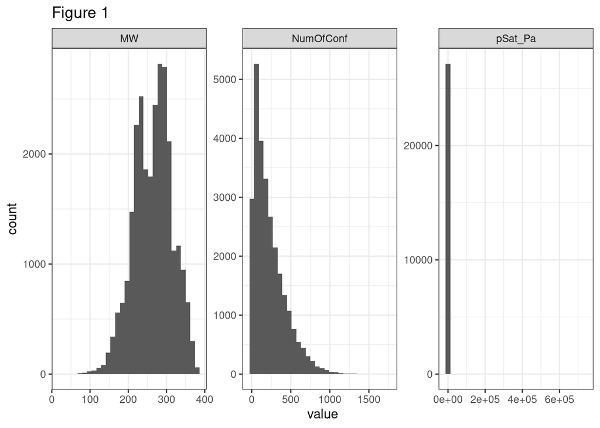

Following the initial categorization of features, a tailored approach to classify numeric features into ordinal and continuous was adopted based on their characteristics. Ordinal features, identified by less than 50 unique values, did not undergo transformations and retained their ordinal nature to ensure the preservation of critical data meaning. This was decided in recognizing the importance of preserving the ordinal nature of the data, particularly when the order holds significant meaning and so we decided against transforming ordinal features to normality.

Conversely, continuous features were marked by a cutoff of more 50 unique values. However, scrutiny of the initial distribution of continuous variables revealed skewness, as depicted in Figure 1. In response, we explored the application of logarithmic transformations on these variables to approximate normality. This transformation resulted in the creation of three additional variables prefixed with “trans_.” This consideration aimed to mitigate the observed skewness and enhance the normality of the continuous variables for improved model performance.

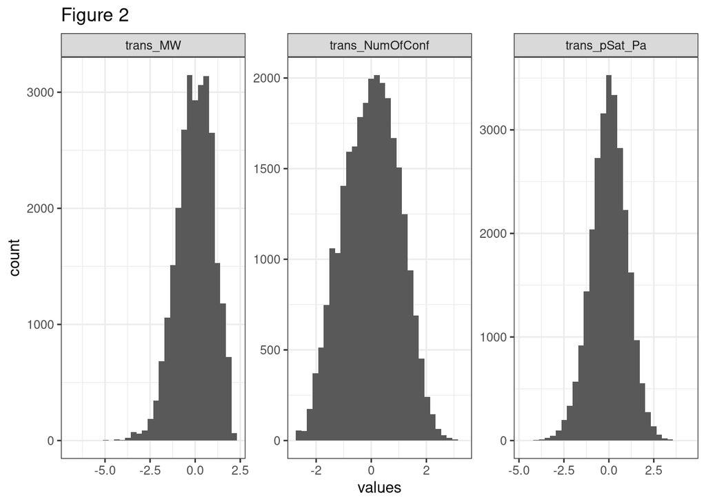

We undertook uniform scaling on the entire dataset, which included both continuous and ordinal data, while excluding discrete features. This scaling aimed to address variations in the number of levels across different features, promoting a more consistent and comparable dataset and contributing to its approximation of normality, as shown in Figure 2.

Although the dataset was examined for outliers, a decision was made to leave them untreated due to a lack of domain knowledge. This cautious approach was particularly important to prevent outliers from unduly influencing subsequent modeling phases. Notably, as researchers not involved in the data collection process and lacking expertise in the specific domain of chemistry, determining whether a value is an outlier or not became a challenging task. An important consideration in our approach was acknowledging the difficulty of defining outliers in categorical variables, as some values may not be outliers but rather rare categories or levels. Consequently, outliers were only identified and examined in the context of transformed continuous variables, as opposed to categorical variables. Specifically, we defined outliers as values deviating more than 3.29 standard deviations from the mean in the present analysis.

##### Figure 3

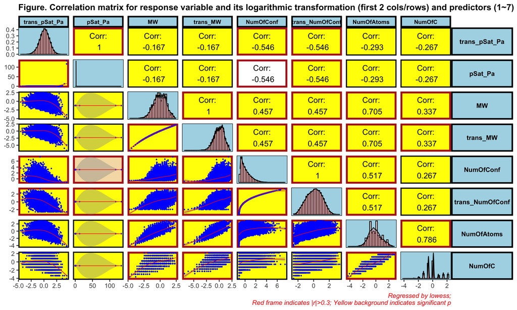

##### Figure 4

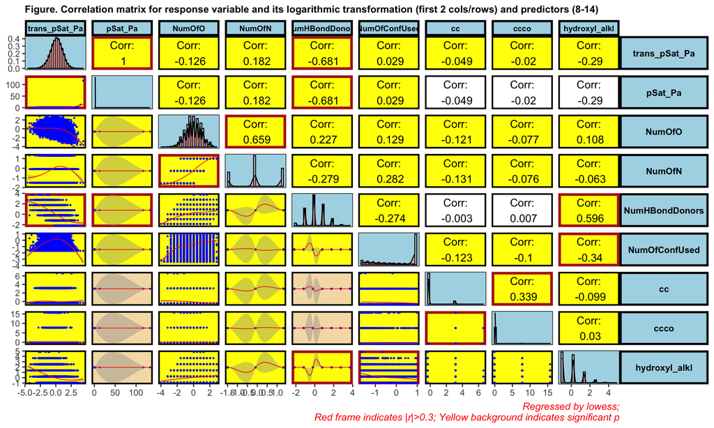

##### Figure 5

[figure not shown]

##### Figure 6

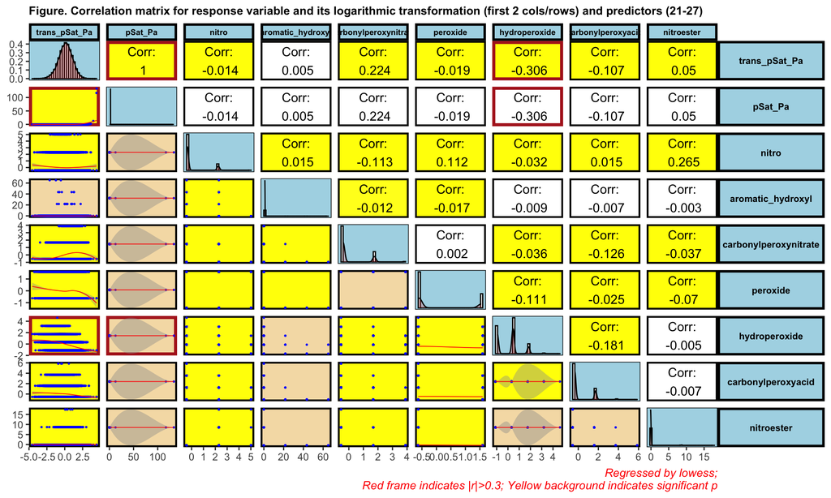

In enhancing our capacity to capture intricate relationships within the data, we strategically introduced novel features. These additions included a weighted sum of functional groups, an interaction term accounting for the joint effects of molecular weight and hydroxyl groups, and principal components derived from variables bearing the label “Num” in their names. These novel features, prefixed with “new_,” were exploratory in nature, aimed at providing a more nuanced understanding of the molecular characteristics under consideration. Notably, we introduced an interaction term between molecular weight and hydroxyl groups to comprehensively account for their combined influence on vapor pressure. Moreover, the derivation of polarity scores which incorporated weighted functional groups, also offered a refined measure of molecular characteristics.

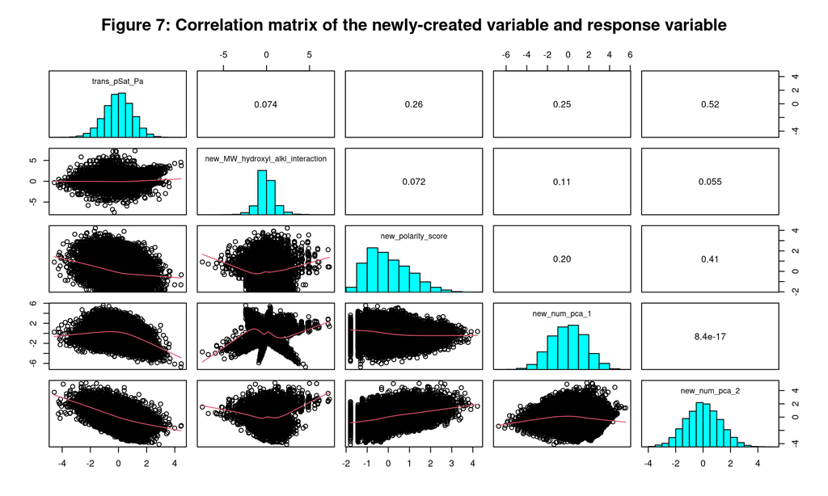

The correlation matrix revealed high collinearity among the new features with the “Num” label in their names. To address this, an attempt was made to condense them into a reduced set of variables using Principal Component Analysis, with a subsequent examination of their correlation with the response variable. A cautionary note was issued regarding the usage of these newly introduced variables, urging careful consideration due to their exploratory nature.

Lastly, we presented use cases showcasing the creation of a final dataset that included both original and generated variables. For modeling purposes, the inclusion of variables prefixed with “new_” was discouraged, emphasizing the preference for transformed continuous variables marked with “trans_” in their names. The discrete variable “parentspecies” underwent one-hot encoding, providing suitable alternatives for machine learning algorithms. The recommended dataset for the machine learning task encompassed all original variables as their scaled version, transformed continuous variables, and the replacement of the original multi-level variable “parentspecies” with its one-hot encoding equivalents. Importantly, newly created variables were excluded from this preferred set. These steps were aimed at optimizing the dataset for the ensuing machine learning analysis while emphasizing clarity and efficiency in variable selection.

# Machine Learning Approach

As an initial step in finding the best model for our task, we assessed the performance of various regression models through comprehensive cross-validation on the training dataset. The chosen models encompass a diverse range of approaches commonly employed in regression problem-solving. Models selected for evaluation include:

- linear regression, incorporating Lasso and Ridge regularization techniques for enhanced robustness,
- random forest model known for its ensemble learning capabilities,
- support vector regressor leveraging radial basis function kernels
- gradient boosting regressor recognized for its ability to optimize predictive accuracy.

The rationale behind opting for these specific models lies in their versatility and popularity within the machine learning domain, providing a well-rounded exploration of regression methodologies. They are also well aligned with the contents of the course and will give us an opportunity to better understand their inner workings. The comparative analysis of these models will contribute valuable insights into their effectiveness for the given dataset, guiding subsequent steps in the model selection process.

### 1. Baseline performance

#### Table 1

|  | baseline |
| --- | --- |
| lin_reg | 0.709666 |
| rf | 0.714040 |
| svr | 0.747972 |
| gbr | 0.723740 |
| elasticnet | 0.707905 |

### 2. Feature and Parameter Selection

Following the computation of baseline scores, the focus shifts to feature selection, a critical step in enhancing model efficiency. Several techniques are employed for this purpose, ensuring a comprehensive exploration of the feature space. In our experiments we tested the following approaches:

- feature selection based on the coefficients of the regularized linear regression model,
- feature selection based on F-scores of each feature
- incorporation of Principal Component Analysis (PCA) to discern the pivotal components in the transformed feature space
- utilization polynomial feature transformation to discover non-linear relationships between features

This multifaceted approach to feature selection was driven by a synthesis of statistical analysis, data exploration, and machine learning methodologies familiar to us. The culmination of these efforts results in four distinct set of features, strategically chosen to optimize regression error while mitigating model complexity.

The subsequent phase involves fine-tuning model parameters through cross-validation techniques, a pivotal step to ensure the model’s robustness and generalizability across diverse datasets. The overarching goal is to craft a model that adeptly balances complexity and accuracy, aligning with the specific requirements of the regression task at hand.

#### a) Feature selection based on the coefficients of the regularized linear regression model

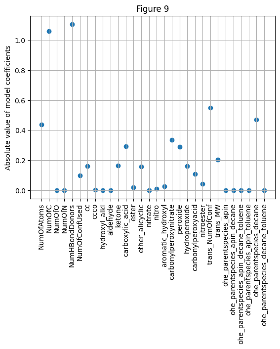

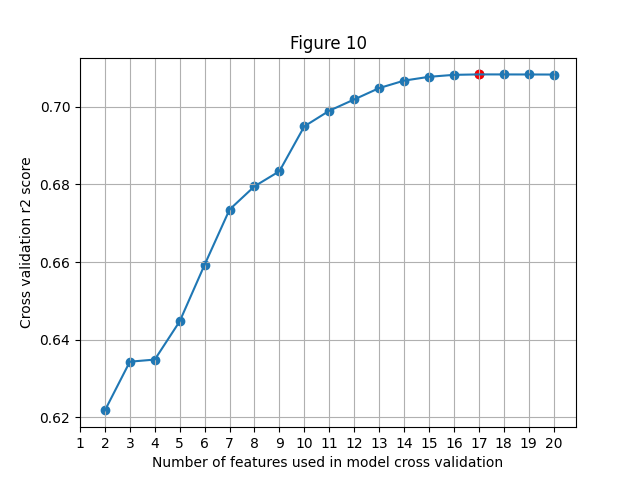

In the initial stage of feature selection, we focused on leveraging the coefficients of a linear regression model with regularization. Our idea was to fit a model with both Lasso and Ridge regularization terms and then analyze its coefficients. Plot on Figure 9 shows the absolute values of such linear regression model coefficients. As can be seen there, a lot of the features have very small coefficients.

By assessing the weights assigned to each feature in the linear regression model, we gained insights into their individual contributions to the target variable. Features exhibiting substantial coefficients are deemed more influential, guiding the selection process towards those with significant predictive power. Figure 10 shows the cross validation r2 score, achieved on subsets of features. The features were added sequentially with decreasing feature coefficient. Red dot on the plot shows a feature subset with the best cross-validation score, which contained 17 features. Even though there were smaller subsets with comparable r2 score, we chose to use the one with the best score. Our experiments showed that models fitted on smaller subsets of features didn’t perform better on test set. This approach provided a foundation for identifying and retaining features that play a pivotal role in enhancing the model’s accuracy and effectiveness.

#### b) Feature selection based on F-scores of each feature

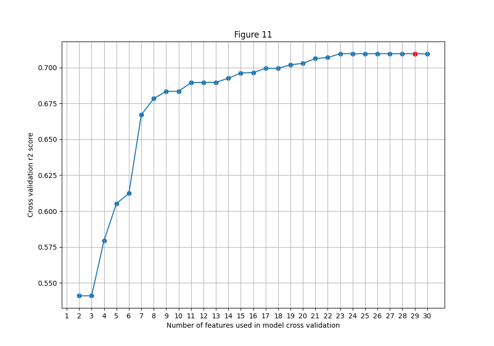

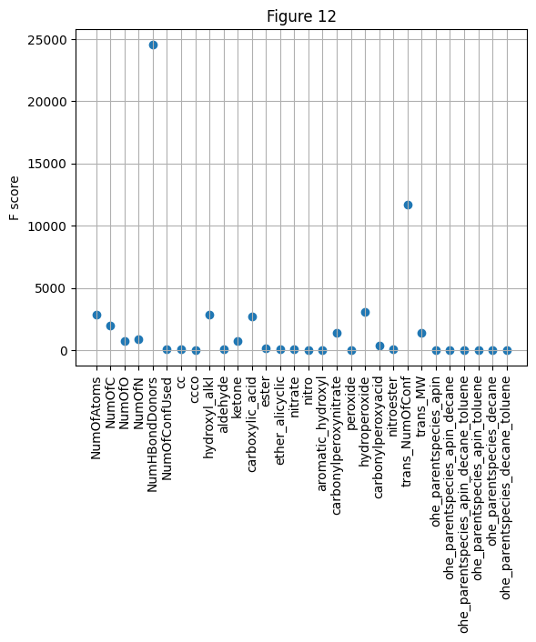

#### c) Incorporation of PCA

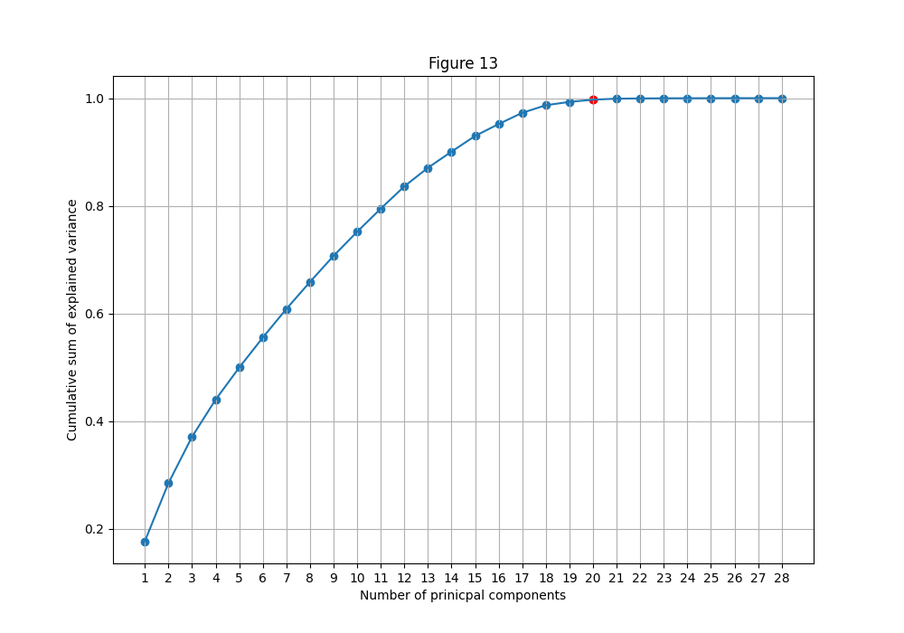

Our next approach involves utilizing Principal Component Analysis (PCA). By analyzing the cumulative sum of explained variance in relation to the number of principal components, we gained valuable insights into the optimal dimensionality reduction. In this context, Figure 13 depicts the cumulative sum of explained variance on the y-axis and the number of principal components on the x-axis. Point marked with red dot in the plot, signifies the optimal number of principal components that effectively capture the dataset’s variability. Striking a balance between dimensionality reduction and retaining crucial information, this step contributed significantly to the refinement of our feature set. The best number of principal components at 20 serve as a judicious selection to preserve essential information while enhancing model generalization capabilities.

#### d) Utilization of polynomial features

The last approach to feature selection we used, was to add new features, created as polynomial combinations of existing features. We included polynomial relations of degree 2. This approach ensured that non-linear relationships between features, were included in the dataset. The assumption that there were non-linear relations in the dataset, was based on the baseline results of our selected models. Support Vector Regressor that utilized non-linear kernels, achieved best r2 score.

# Final results

#### Table 2

|  | baseline | lin reg features | skb features | pca | Polynomial features |
| --- | --- | --- | --- | --- | --- |
| lin_reg | 0.709666 | 0.708340 | 0.709697 | 0.709684 | 0.746813 |
| rf | 0.714040 | 0.704838 | 0.713530 | 0.710483 | 0.715941 |
| svr | 0.747972 | 0.741367 | 0.748168 | 0.747972 | 0.737504 |
| gbr | 0.723740 | 0.718606 | 0.723827 | 0.704239 | 0.728260 |
| elasticnet | 0.707905 | 0.708032 | 0.707976 | 0.707652 | 0.742700 |

In our final project phase, we used all of the knowledge gained during data exploration and applied it to fit a group of models. Table 2 summarizes the results of our rigorous training and feature engineering experiments. Each row of the table contains r2 cross validation scores for given model, achieved on specific dataset.

- SVR fitted on all features
- SVR fitted on F-score selected features
- SVR fitted on PCA transformed features
- Gradient Boosting Regressor fitted on F-score selected features
- Gradient Boosting Regressor fitted on polynomial features
- Linear regression with regularization (ElasticNet) fitted on polynomial features

We scored each of these models on Kaggle and achieved the best score of 0.69698 for the ElasticNet model, and the worst score of 0.68465 for the Gradient Boosting Regressor fitted on F-score selected features. To better understand differences between our models, we did a thorough analysis of the results. Figure 14 shows differences in the distributions of predicted target value for the best and the worst models.

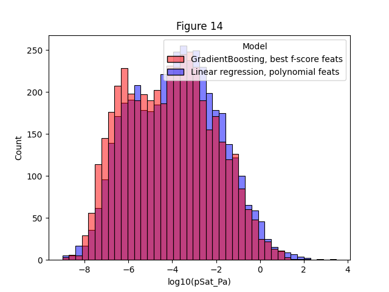

Looking at the differences in predicted values distributions, gave us an idea to create an ensemble model, which would average the scores of the selected 6 models. This approach achieved an r2 score of **0.70564** on Kaggle and turned out to be our best.

# Conclusion

The key insights that we obtained after this project are:

As well, in the iterative wrangling phase of creating our ML model, we identified additional wrangling needs to further refine our dataset. Firstly, we created an unscaled log base 10 version of the response variable, trans_log10_noscale_pSat_Pa, to potentially improve model performance. We also addressed the presence of outliers in the dataset. An outlier flag was introduced as a binary variable, flag_outlier, indicating whether a data point was considered an outlier based on predetermined criteria. These criteria involved examining the standardized values of the response variable, trans_log10_noscale_pSat_Pa, as well as the transformed variables trans_MW and trans_NumOfConf. Any case with at least one outlier was flagged with a value of 1, while non-outliers received a value of 0. The dataset with outlier flags, named gecko_ml_outlier_flag, was then used to create a new dataset, gecko_ml_no_outlier, by filtering out all cases flagged as outliers.

# Self-Grading Report

As well, our group decided to give ourselves a 5, as we worked very effectively and efficiently with each other. We had on point conversations, and utilized our own individual skills to further and enhance our objectives. Moreover, all three of us contributed our ideas, and took responsibility to ensure that our work was completed to the utmost quality. There were absolutely no arguments, and the environment we worked in was very inclusive and accepting of different ideas. In the end, all three of us learned applicable skills throughout this project that would serve us well in the future, and we plan to stay friends afterwards as well.